# Homework 2

Jacob Harrell

2/14/2021

1. Calculate the residuals. Provide summary of residuals. Plot a histogram of the residuals. Do the residuals appear to be Gaussian?

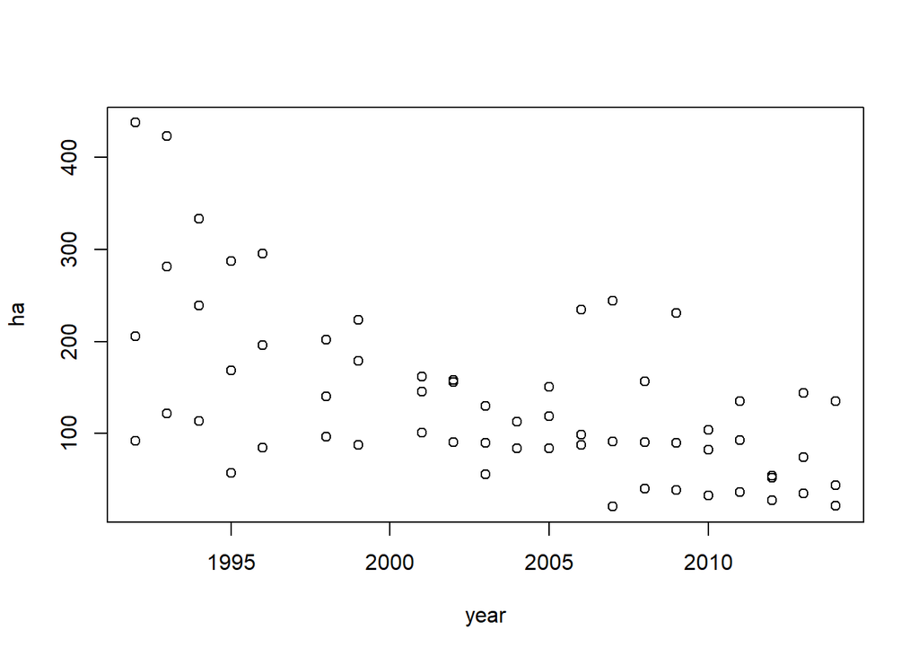

```r
#setwd(choose.dir("New_Folder"))
beach <- read.csv(file='beach.csv')

plot(beach$Year, beach$OpenBeach, xlab='year', ylab='ha')
```

```r
fit <- lm(formula= OpenBeach ~ Year * BeachID, data = beach)
summary(fit)
```

```
##
## Call:
## lm(formula = OpenBeach ~ Year * BeachID, data = beach)
##
## Residuals:
##     Min      1Q  Median      3Q     Max
## -80.203 -21.460  -1.434  13.385  89.529
##
## Coefficients:
##                 Estimate Std. Error t value Pr(>|t|)
## (Intercept)    36945.725   2547.493  14.503  < 2e-16 ***
## Year             -18.365      1.272 -14.443  < 2e-16 ***
## BeachIDB      -34211.979   3602.404  -9.497 2.87e-13 ***
## BeachIDC      -28776.115   3602.404  -7.988 8.09e-11 ***
## Year:BeachIDB     17.043      1.798   9.478 3.07e-13 ***
## Year:BeachIDC     14.371      1.798   7.992 7.96e-11 ***
## ---
## Signif. codes:  0 '***' 0.001 '**' 0.01 '*' 0.05 '.' 0.1 ' ' 1
##
## Residual standard error: 39.46 on 56 degrees of freedom
## Multiple R-squared:  0.8298, Adjusted R-squared:  0.8146
## F-statistic: 54.62 on 5 and 56 DF,  p-value: < 2.2e-16
```

```r
fit.res <- resid(fit)
summary(fit.res)
```

```
##    Min. 1st Qu.  Median    Mean 3rd Qu.    Max.
## -80.203 -21.460  -1.434   0.000  13.385  89.529
```

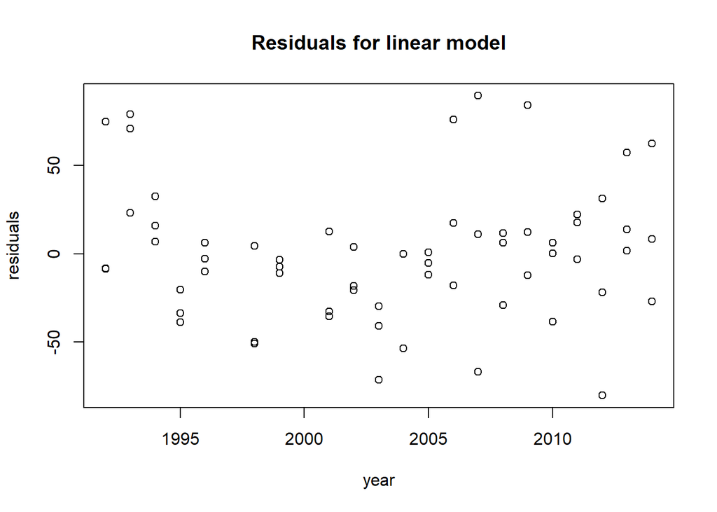

```r
plot(beach$Year, fit.res, ylab = "residuals", xlab = "year", main = "Residuals for linear model")
```

```r
summary(fit.res)
```

```
##    Min. 1st Qu.  Median    Mean 3rd Qu.    Max.
## -80.203 -21.460  -1.434   0.000  13.385  89.529
```

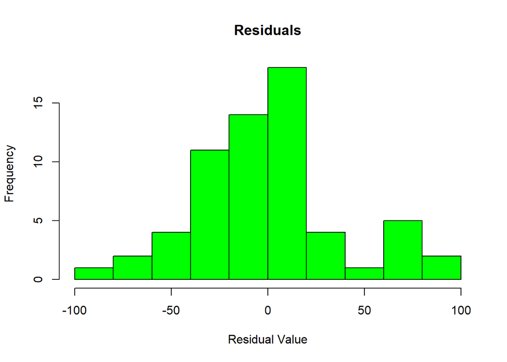

```r
hist(fit.res, xlab = "Residual Value", main = "Residuals", col = "green", border = "black")
```

The residuals have certain qualities that may identify them as a Gaussian model. There is a distinct bell-shpaed curve when plotted on a histogram. This curve is much more defined to the left of the 0-point residual and weakly defined to the right of it.

2. Calculate test statistics for regression coefficients. Verify by comparing test statistics reported from the model output.

```r
#setwd(choose.dir("New_Folder"))
beach<-read.csv(file='beach.csv')

fit <- lm(formula= OpenBeach ~ Year * BeachID, data = beach)

ts1<-coef(fit)[2]/summary(fit)[['coefficients']]['Year', 'Std. Error']
ts1
```

```
##      Year
## -14.44263
```

```r
ts2<-coef(fit)[3]/summary(fit)[['coefficients']]['BeachIDB','Std. Error']
ts2
```

```
##  BeachIDB
## -9.496986
```

```r
ts3<-coef(fit)[4]/summary(fit)[['coefficients']]['BeachIDC','Std. Error']
ts3
```

```
##  BeachIDC
## -7.988032
```

```r
ts4<-coef(fit)[5]/summary(fit)[['coefficients']]['Year:BeachIDB','Std. Error']
ts4
```

```
## Year:BeachIDB
##      9.478096
```

```r
ts5<-coef(fit)[6]/summary(fit)[['coefficients']]['Year:BeachIDC','Std. Error']
ts5
```

```
## Year:BeachIDC
##      7.992408
```

```r
summary(fit)
```

```
##
## Call:
## lm(formula = OpenBeach ~ Year * BeachID, data = beach)
##
## Residuals:
##     Min      1Q  Median      3Q     Max
## -80.203 -21.460  -1.434  13.385  89.529
##
## Coefficients:
##                 Estimate Std. Error t value Pr(>|t|)
## (Intercept)    36945.725   2547.493  14.503  < 2e-16 ***
## Year             -18.365      1.272 -14.443  < 2e-16 ***
## BeachIDB      -34211.979   3602.404  -9.497 2.87e-13 ***
## BeachIDC      -28776.115   3602.404  -7.988 8.09e-11 ***
## Year:BeachIDB     17.043      1.798   9.478 3.07e-13 ***
## Year:BeachIDC     14.371      1.798   7.992 7.96e-11 ***
## ---
## Signif. codes:  0 '***' 0.001 '**' 0.01 '*' 0.05 '.' 0.1 ' ' 1
##
## Residual standard error: 39.46 on 56 degrees of freedom
## Multiple R-squared:  0.8298, Adjusted R-squared:  0.8146
## F-statistic: 54.62 on 5 and 56 DF,  p-value: < 2.2e-16
```

3. Calculate p-values for regression coefficients. Verify values with model output. Waht are the associated null hypotheses? Do we reject or fail to reject these hypotheses?

```r
#setwd(choose.dir("New_Folder"))
beach<-read.csv(file='beach.csv')

fit <- lm(formula= OpenBeach ~ Year * BeachID, data = beach)

#p-value regression coefficient 1
pt(q=ts1, df=nrow(beach)-length(coef(fit)))*2
```

```
##         Year
## 1.558806e-20
```

```r
summary(fit)[['coefficients']]['Year','Pr(>|t|)']
```

```
## [1] 1.558806e-20
```

```r
#p-value regression coefficient 2
pt(q=ts2, df=nrow(beach)-length(coef(fit)))*2
```

```
##     BeachIDB
## 2.868075e-13
```

```r
summary(fit)[['coefficients']]['BeachIDB','Pr(>|t|)']
```

```
## [1] 2.868075e-13
```

```r
#p-value regression coefficient 3
pt(q=ts3, df=nrow(beach)-length(coef(fit)))*2
```

```
##     BeachIDC
## 8.090204e-11
```

```r
summary(fit)[['coefficients']]['BeachIDC','Pr(>|t|)']
```

```
## [1] 8.090204e-11
```

```r
#p-value regression coefficient 4
pt(q=ts4, df=nrow(beach)-length(coef(fit)))*2
```

```
## Year:BeachIDB
##             2
```

```r
summary(fit)[['coefficients']]['Year:BeachIDB','Pr(>|t|)']
```

```
## [1] 3.07437e-13
```

```r
#p-value regression coefficient 5
pt(q=ts5, df=nrow(beach)-length(coef(fit)))*2
```

```
## Year:BeachIDC
##             2
```

```r
summary(fit)[['coefficients']]['Year:BeachIDC','Pr(>|t|)']
```

```
## [1] 7.957165e-11
```

In each instance, the null hypotheses for the regression coefficients is that the coefficient associated with the respective variable at ‘year’, ‘beachIDB’, ‘beachIDC’, ‘year:BeachIDB’, and ’year:beachIDC’equals zero. Because each respective p-value is smaller than any reasonable a, in each instance the null hypotheses would be rejected.

4. Select a single regression coefficient. Devise a null hypothesis different from the default. Report test statistics, p-value, and whether the null hypothesis is rejected or fails to reject.

In this instance, I have selected the regression coefficient ‘BeachIDB’ for further analysis.The null hypothesis in this case is that BeachIDB=100.

```r
#setwd(choose.dir("New_Folder"))
beach<-read.csv(file='beach.csv')

fit <- lm(formula= OpenBeach ~ Year * BeachID, data = beach)

ts_new<-(coef(fit)[3]-100)/summary(fit)[['coefficients']]['BeachIDB','Std. Error']
ts_new
```

```
##  BeachIDB
## -9.524746
```

```r
pt(q=ts_new, df=nrow(beach)-length(coef(fit)))*2
```

```
##     BeachIDB
## 2.589939e-13
```

```r
summary(fit)[['coefficients']]['BeachIDB','Pr(>|t|)']
```

```
## [1] 2.868075e-13
```

We would reject the null hypothesis because the associated p-value is smaller than any reasonable a.

5. Interpret output of the fitted model. How does the beach area change through time at each of the three beaches?

```r
#setwd(choose.dir("New_Folder"))
beach<-read.csv(file='beach.csv')

fit <- lm(formula= OpenBeach ~ Year * BeachID, data = beach)

change<-coef(fit)
#beach A
change[2]
```

```
##      Year
## -18.36491
```

```r
#beach B
change[2]+change[5]
```

```
##      Year
## -1.322145
```

```r
#beach C
change[2]+change[6]
```

```
##      Year
## -3.993592
```

Based on the fitted model, there is evidence that each beach experiences a statistical decline in open beach area. Beach A has an annual decline of 18.36491 hectares. Beach B has an annual decline of 1.322145 hectares. Beach C has an annual decline of 3.993592 hectares.